# LBB Regression Models

Enlik

14 February 2019

# What is Regression Analysis?

In statistical modeling, regression analysis is a set of statistical processes for estimating the relationships among variables. It includes many techniques for modeling and analyzing several variables, when the focus is on the relationship between a dependent variable and one or more independent variables. [Wikipedia](https://en.wikipedia.org/wiki/Regression_analysis).

One of the functions from regression analysis is to build prediction models.

# Introduction

This dataset (insurance) source was from [Kaggle](https://www.kaggle.com/mirichoi0218/insurance). It contains 1,338 observations and 7 variables:

1. age
2. sex
3. bmi (Body Mass Index)
4. children (Their Total Children)
5. smoker
6. region
7. charges (Medical Charges)

# Required Libraries

```r
library(MASS)
library(car)
```

# Read data

```r
insurance <- read.csv("insurance.csv")

head(insurance)
```

```
##   age    sex    bmi children smoker    region   charges
## 1  19 female 27.900        0    yes southwest 16884.924
## 2  18   male 33.770        1     no southeast  1725.552
## 3  28   male 33.000        3     no southeast  4449.462
## 4  33   male 22.705        0     no northwest 21984.471
## 5  32   male 28.880        0     no northwest  3866.855
## 6  31 female 25.740        0     no southeast  3756.622
```

```r
summary(insurance)
```

```
##       age            sex           bmi           children     smoker
##  Min.   :18.00   female:662   Min.   :15.96   Min.   :0.000   no :1064
##  1st Qu.:27.00   male  :676   1st Qu.:26.30   1st Qu.:0.000   yes: 274
##  Median :39.00                Median :30.40   Median :1.000
##  Mean   :39.21                Mean   :30.66   Mean   :1.095
##  3rd Qu.:51.00                3rd Qu.:34.69   3rd Qu.:2.000
##  Max.   :64.00                Max.   :53.13   Max.   :5.000
##        region       charges
##  northeast:324   Min.   : 1122
##  northwest:325   1st Qu.: 4740
##  southeast:364   Median : 9382
##  southwest:325   Mean   :13270
##                  3rd Qu.:16640
##                  Max.   :63770
```

```r
table(insurance$children)
```

```
##
##   0   1   2   3   4   5
## 574 324 240 157  25  18
```

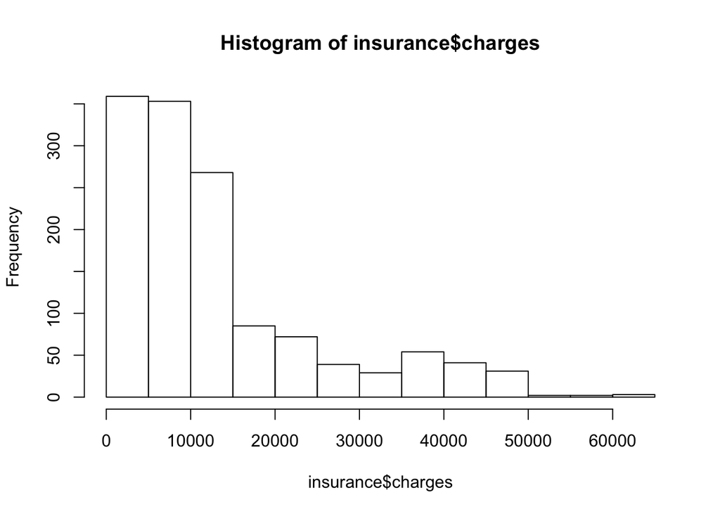

```r
hist(insurance$charges)
```

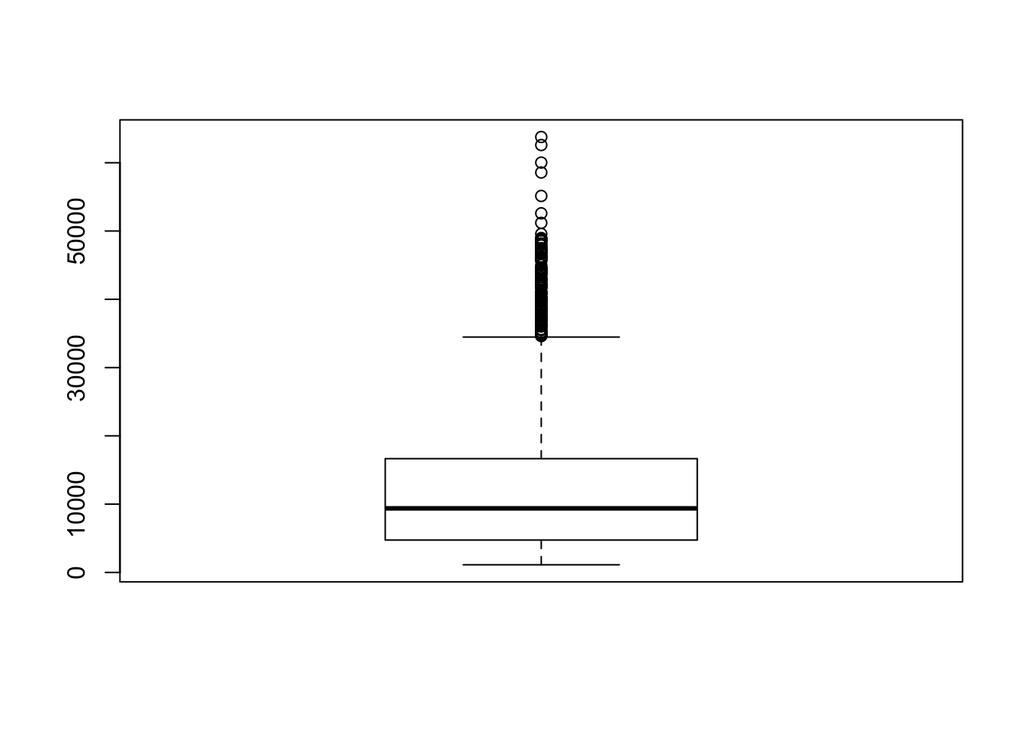

```r
boxplot(insurance$charges)
```

# Are medical charges have any relationship with other variables?

H0 = no relation between any predictors and the response (tested by F-statistic value). The p-value of F-statistic can be used to determine whether the H0 can be rejected or not.

Here is multiple linear regression model using all the predictors:

```r
lm1 <- lm(formula = charges ~ ., data = insurance)
summary(lm1)
```

```
##
## Call:
## lm(formula = charges ~ ., data = insurance)
##
## Residuals:
##      Min       1Q   Median       3Q      Max
## -11304.9  -2848.1   -982.1   1393.9  29992.8
##
## Coefficients:
##                 Estimate Std. Error t value Pr(>|t|)
## (Intercept)     -11938.5      987.8 -12.086  < 2e-16 ***
## age                256.9       11.9  21.587  < 2e-16 ***
## sexmale           -131.3      332.9  -0.394 0.693348
## bmi                339.2       28.6  11.860  < 2e-16 ***
## children           475.5      137.8   3.451 0.000577 ***
## smokeryes        23848.5      413.1  57.723  < 2e-16 ***
## regionnorthwest   -353.0      476.3  -0.741 0.458769
## regionsoutheast  -1035.0      478.7  -2.162 0.030782 *
## regionsouthwest   -960.0      477.9  -2.009 0.044765 *
## ---
## Signif. codes:  0 '***' 0.001 '**' 0.01 '*' 0.05 '.' 0.1 ' ' 1
##
## Residual standard error: 6062 on 1329 degrees of freedom
## Multiple R-squared:  0.7509, Adjusted R-squared:  0.7494
## F-statistic: 500.8 on 8 and 1329 DF,  p-value: < 2.2e-16
```

A high value of F statistic (500.8), with a very low p-value (<2.2e-16) means there is a potential relationship between the predictors and the outcome.

R-squared ($R^2$) measures the proportion of variability in the outcome that can be explained by the model, and is always between 0 and 1. The higher the value, the better the model is able to explain the variability in the outcome.

# Validation of Regression Analysis

## Which variables have a strong relation to “medical charges” variable?

We will finding out if all or only some of the predictors are related to the outcome.

Linear regression using the features with significant p-values only.

```r
lm1.sel <- lm(charges~age+bmi+children+smoker+region, data = insurance)
```

Using `stepAIC()`, we will compare this to mixed selection, which is a combination of “forward”" and “backward” selection, to select the best model out of multiple models.

```r
step1 <- stepAIC(lm1, direction = "both", trace = FALSE)
```

## Compare Two Models

```r
step1$call
```

```
## lm(formula = charges ~ age + bmi + children + smoker + region,
##     data = insurance)
```

```r
lm(formula = charges ~ age + bmi + children + smoker + region,
    data = insurance)
```

```
##
## Call:
## lm(formula = charges ~ age + bmi + children + smoker + region,
##     data = insurance)
##
## Coefficients:
##     (Intercept)              age              bmi         children
##        -11990.3            257.0            338.7            474.6
##       smokeryes  regionnorthwest  regionsoutheast  regionsouthwest
##         23836.3           -352.2          -1034.4           -959.4
```

```r
lm1.sel$call
```

```
## lm(formula = charges ~ age + bmi + children + smoker + region,
##     data = insurance)
```

```r
lm(formula = charges ~ age + bmi + children + smoker + region,
    data = insurance)
```

```
##
## Call:
## lm(formula = charges ~ age + bmi + children + smoker + region,
##     data = insurance)
##
## Coefficients:
##     (Intercept)              age              bmi         children
##        -11990.3            257.0            338.7            474.6
##       smokeryes  regionnorthwest  regionsoutheast  regionsouthwest
##         23836.3           -352.2          -1034.4           -959.4
```

The model given by *stepwise* selection is same as the model we got by selecting the predictors with significant p-values.

# Multicollinearity Assumption Checking

Multicollinearity is a phenomenon when two or more predictors are highly related to each other, and then one predictor can be used to predict the value of the other predictor.

Multicollinearity can be detected using the **Variance Inflation Factor (VIF)**.

Usually, a VIF value of above 5 or 10 is taken as an indicator of multicollinearity.

The simplest way of getting rid of multicollinearity in that case is to discard the predictor with high value of VIF.

```r
vif(step1)
```

```
##              GVIF Df GVIF^(1/(2*Df))
## age      1.016188  1        1.008061
## bmi      1.104197  1        1.050808
## children 1.003714  1        1.001855
## smoker   1.006369  1        1.003179
## region   1.098870  3        1.015838
```

None of the predictors in this case has a high value of VIF. Because of that, we don’t need to worry about multicollinearity in our case.

# Residual Plot

Residual for any observation is the difference between the actual outcome and the fitted outcome as per the model.

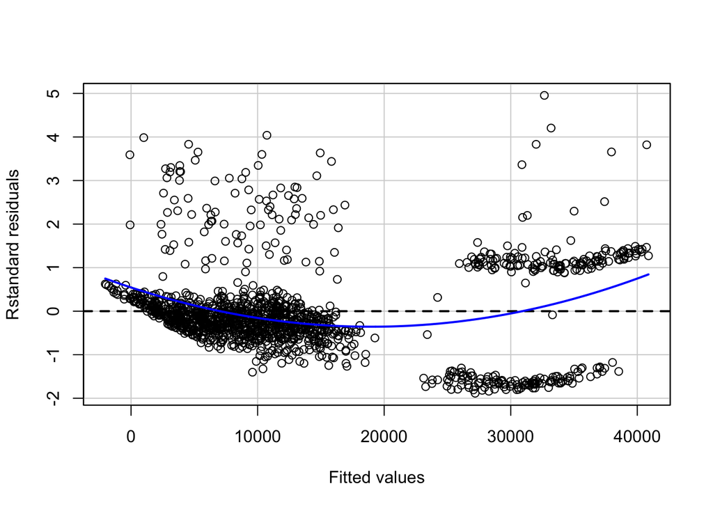

```r
residualPlot(step1, type = "rstandard")
```

```r
summary(step1$residuals)
```

```
##     Min.  1st Qu.   Median     Mean  3rd Qu.     Max.
## -11367.2  -2835.4   -979.7      0.0   1361.9  29935.5
```

The blue line means there is a smooth pattern between the fitted values and the standard residuals. The curve means slight non-linearity in this data.